# Logboek-Storm

### Bekijken Data

Ook ga ik wat meer naar de data kijken. Er zijn nog een paar dingen die ik mij afvraag.

De eerste vraag is of er een verband zit tussen de mensen die hun fysieke gesteldheid belangrijk vinden en hoe blij ze zijn met hun fysieke gesteldheid.

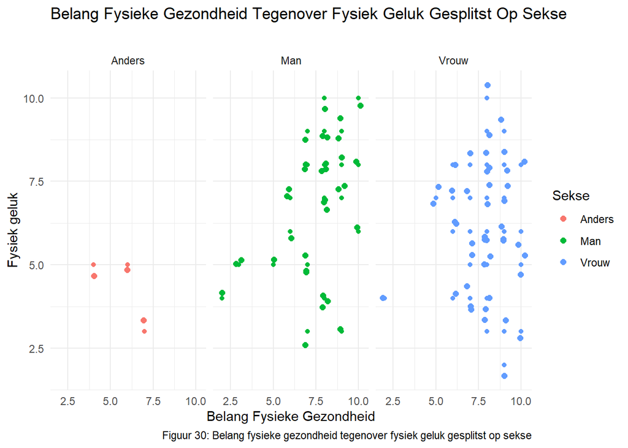

```r
js_scatterplot(data = numerieke_data, x= numerieke_data$Belang_Fysieke_Gezondheid, y= numerieke_data$Fysiek_Geluk, fill = data$Sexe, facet_wrap = "~data$Sexe",title = "Belang Fysieke Gezondheid Tegenover Fysiek Geluk Gesplitst Op Sekse", legend_title = "Sekse", xlab= "Belang Fysieke Gezondheid", ylab= "Fysiek geluk", caption = "Figuur 30: Belang fysieke gezondheid tegenover fysiek geluk gesplitst op sekse")
```

Hierboven zie je een spreidingsdiagram van het belang van de fysieke gezondheid voor het geluk tegenover fysiek geluk gesplitst op sekse. Wat opvalt is dat bij de vrouwen de punten heel erg verspreid zijn. Dus daar zit zeker geen correlatie tussen de twee variabelen. Wat ook opvalt is dat de groep anders te klein is om er iets uit te kunnen trekken. De mannen daarentegen lijken steeds gelukkiger te zijn met hun lichaam hoe belangrijker ze fysieke gezondheid vinden.

Het tweede wat ik mij afvraag is hoe de verdeling van de seske over de vakgebieden is.

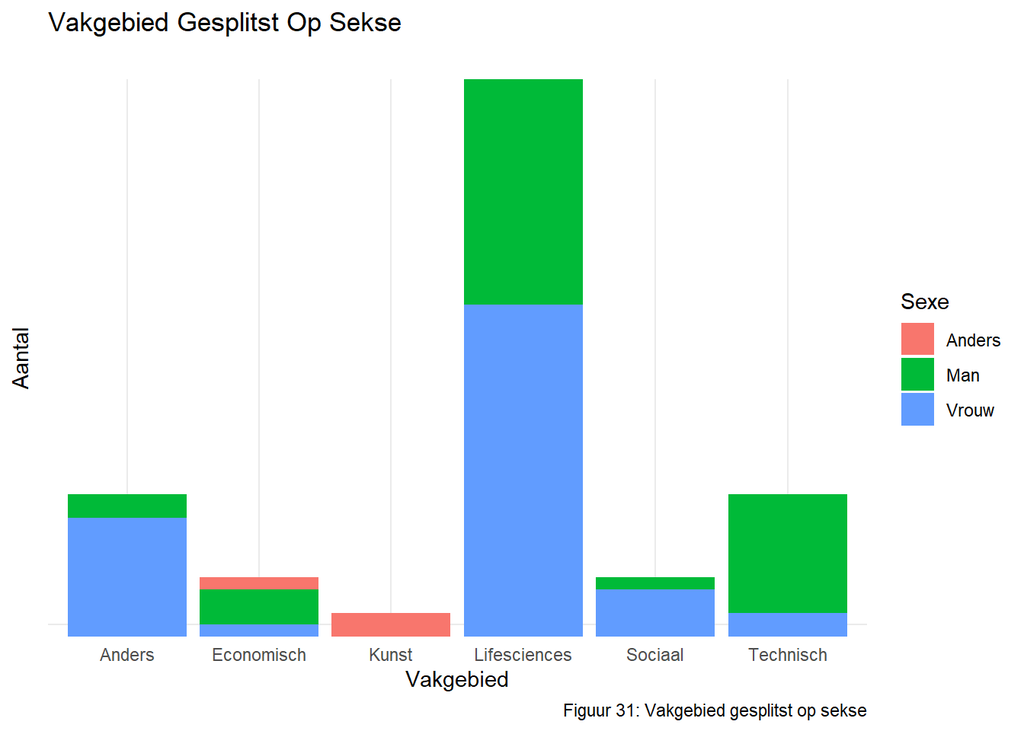

```r
js_barchart(data = data, x= data$Vakgebied, fill = data$Sexe, title = "Vakgebied Gesplitst Op Sekse", ylab= "Aantal", xlab="Vakgebied", legend_title = "Sexe", caption = "Figuur 31: Vakgebied gesplitst op sekse")
```

Hierboven zie je een staafdiagram van de vakgebieden gesplitst op sekse. Wat opvalt is dat de groep anders de enige sekse in de kunst sector is. Wat ook opvalt is dat de vrouwen in de grote meerderheid zijn bij de sociale- en andere sectoren. Verder zijn ze ook de meerderheid in lifesciences, maar dat scheelt niet veel. De mannen zijn allen in de grote meerderheid in de technische sector.

Het laatste wat ik mij afvraag is of uitwonende- of thuiswonende studenten gelukkiger zijn met hun woonsituatie.

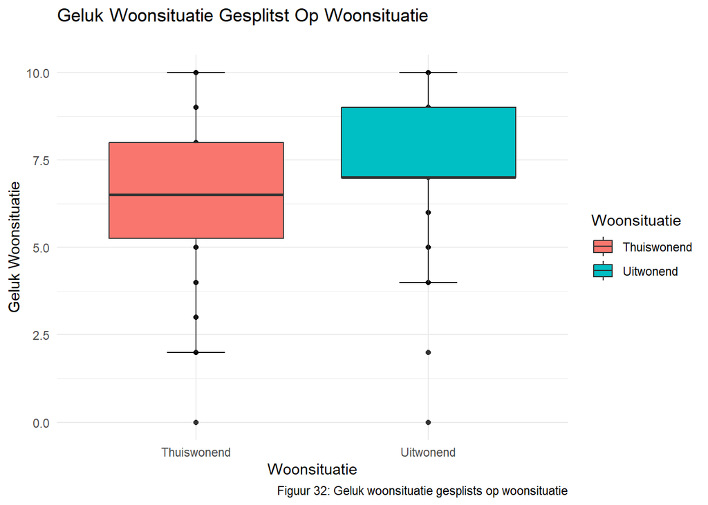

```r
js_boxplot(data = data, x= data$Woonsituatie, y= data$Geluk_Woonsituatie, fill= data$Woonsituatie, title = "Geluk Woonsituatie Gesplitst Op Woonsituatie", legend_title = "Woonsituatie", xlab= "Woonsituatie", ylab= "Geluk Woonsituatie", caption = "Figuur 32: Geluk woonsituatie gesplists op woonsituatie")
```

Hierboven zie je een boxplot van het geluk met de woonsituatie gesplitst op de woonsituatie. Het is te zien dat de uitwonende studenten gemiddeld gelukkiger zijn met hun woonsituatie dan de thuiswonende studenten. Ook is de data van de uitwonende studenten minder verspreid. De minst gelukkige zijn een uitwonende en een thuiswonende student, die hun woonsituatie een 0 gaf.

# 04-06-2024

## Doel

Inleveren eindproduct

## Taken

- Lees alle documenten door
- Verbeter kleine foutjes
- Lever alles in

## Log

Vandaag hoef ik geen verwerking van data meer te doen. Dat is gisteren allemaal afgemaakt, dus lees ik nog alle documenten door om te kijken of ze klaar zijn om in te leveren.

Na het doorlezen van het document heb ik alleen wat spelling- en grammaticafoutjes verbeterd en nog stukjes van de template uit ons einddocument gehaald. In mijn logboek zaten ook een paar spellings- en grammaticafoutjes die ik heb verbeterd. Maar nu ziet alles er goed genoeg uit om in te kunnen leveren.